# q3

Sean O’Rourke

01/08/2021

## Question 3

The first step in this investigation was to select a clustering technique. While there are many computational methods to compare and asses algorithms an emperical approach that factors in the properties of the data and the purpose of the task was the preferred method by this investigation. Firstly it was assumed that the data set had been cleaned and was free from errors (which has been confirmed in latter steps) and any extreme values were genuine cases that needed to be accounted for. The second factor that was considered was the investigations requirement to produce an outcome that is understandable and can be used to further drill down into the data. That is, the purpose of the exercise is to gain an insight into the relationships between the gene groupings rather than simply dropping observations into the correct bucket. These to requirements alleviated the need and ruled out the use of density based clustering methods. Density based methods, while computationally expensive, can be very accurate, especially if one is dealing with data sets that contain outliers that do not need to fall within a cluster. However the outputs of density based methods, especially in higher dimensional space (>3) can be difficult to visualize and interpret. Given there is no strong need for the use of density based clustering in this application it is considered prudent to use a less complicated algorithm. Generally it is considered advantageous to use the simplest algorithm suitable for the data as the simpler the algorithm the more understandable the result is.

This leaves Centroid and Hierarchical based clustering methods to select from. Hierarchical methods have the advantage that they build an easily interpreted tree, which could further inform hypothesis and do not make any assumptions regarding the shape of the clusters or the number of clusters. While the number of clusters was known in this case the assumption that that it is the most prominent pattern in the data can not be easily confirmed. Further in such high dimensional space (~1800 variables) gaining any understanding of the cluster shape is near impossible (without significant dimension reduction which is beyond the scope of this investigation), this lead to the inability to check the assumption of approximately symmetric clusters. For this reason the use of Centroid based methods, such as k-means was considered a poor choice. As discussed below, in high dimensional space, traditional methods used to measure distance can become erroneous and lack meaning. While some evidence of successful adaption of centroid based clustering using variuos distance metrics can be found it is generally poorly documented. Given the scope of this investigation the flexibility of which distance / similarity metric is used suggests Hierarchial clustering would be the most suitable method. Further agglomerate clustering will be used as it is generally more accepted and has much more supporting literature.

With the selection of Hierarchical based agglomerate clustering confirmed the following issues had to be dealt with in a careful manner:

- High sensitivity to outliers, especially since choice made early in thew clustering process carry throughout,
- Highly correlated variables can adversely affect the clustering,
- A meaningful distance measure needs to be used,
- Selection of meaningful cluster assessments to define the best levels to cut the resulting tree (beyond the known 2 clusters).

At this point in the investigation it is worth noting that this investigation, while it is aware of the actual classes of the data, will develop a model independant of this knowledge and then use it to asses the outcomes. As such there was is no need to complete test training splits as the true classes are retained from the model for the entire process upto final evaluation. The following steps have been undertaken to complete the clustering.

```
##  [1] "Gene_8"    "Gene_10"   "Gene_47"   "Gene_91"   "Gene_169"  "Gene_175"
##  [7] "Gene_190"  "Gene_195"  "Gene_268"  "Gene_283"  "Gene_304"  "Gene_354"
## [13] "Gene_371"  "Gene_443"  "Gene_452"  "Gene_457"  "Gene_461"  "Gene_482"
## [19] "Gene_496"  "Gene_505"  "Gene_510"  "Gene_603"  "Gene_657"  "Gene_755"
## [25] "Gene_759"  "Gene_856"  "Gene_1043" "Gene_1087" "Gene_1092" "Gene_1129"
## [31] "Gene_1161" "Gene_1172" "Gene_1284" "Gene_1287" "Gene_1305" "Gene_1320"
## [37] "Gene_1363" "Gene_1370" "Gene_1383" "Gene_1394" "Gene_1408" "Gene_1428"
## [43] "Gene_1525" "Gene_1534" "Gene_1545" "Gene_1579" "Gene_1583" "Gene_1604"
## [49] "Gene_1605" "Gene_1612" "Gene_1619" "Gene_1623" "Gene_1635" "Gene_1647"
```

```
## [1] "total # removed"
```

```
## [1] 54
```

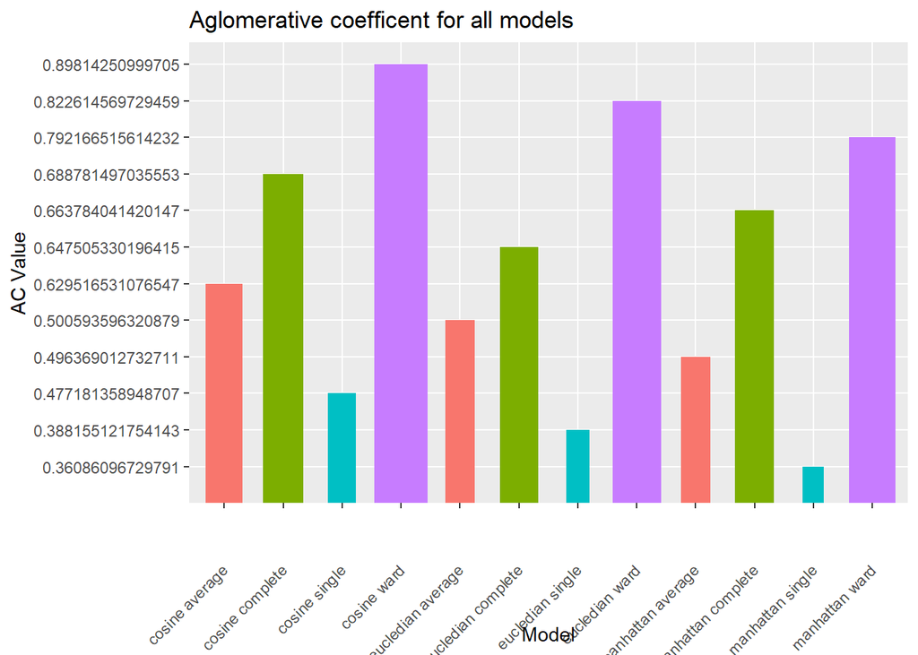

Three dissimilarity matrices were generated to represent the data using the Cosine, Euclidean and Manhattan distances. The selection of an appropriate distance / dissimilarity measure is crucial to the accuracy of any clustering algorithm. While visualizing distances in such high dimensional spaces the following sumarises the effects of each method.

- Cosine simply measures the difference as an angle between the two vectors that would describe each observation. This has the effect of scaling, but not centering the data meaning that the magnitudes of the observations are less important, just the directions in which they lie,
- Euclidean measures the distance between the end of the vectors, which encompasses both the lengths and directions of the vectors,
- Manhattan projects the vectors onto a single 2 dimensional plane and measures the distance along both axes between the ends of the vectors describing each observation.

The agnes() function from the cluster package was then used to generate the cluster assignments for each dissimilarity matrix using the single, complete, average and ward methods. To rank the method the agglomerate coefficient was used. The rankings of the models is shown in the below figure. It is clear that the cosine wards model has the highest degree of structure. This model will now be assessed against the known class labels. As we know we are seeking only 2 clusters we will cut the tree an k = 2 to obtain the classifications.

```
## Confusion Matrix and Statistics
##
##           Reference
## Prediction ALL AML
##        ALL  47   2
##        AML   0  23
##
##                Accuracy : 0.9722
##                  95% CI : (0.9032, 0.9966)
##     No Information Rate : 0.6528
##     P-Value [Acc > NIR] : 3.51e-11
##
##                   Kappa : 0.9376
##
##  Mcnemar's Test P-Value : 0.4795
##
##             Sensitivity : 1.0000
##             Specificity : 0.9200
##          Pos Pred Value : 0.9592
##          Neg Pred Value : 1.0000
##              Prevalence : 0.6528
##          Detection Rate : 0.6528
##    Detection Prevalence : 0.6806
##       Balanced Accuracy : 0.9600
##
##        'Positive' Class : ALL
##
```

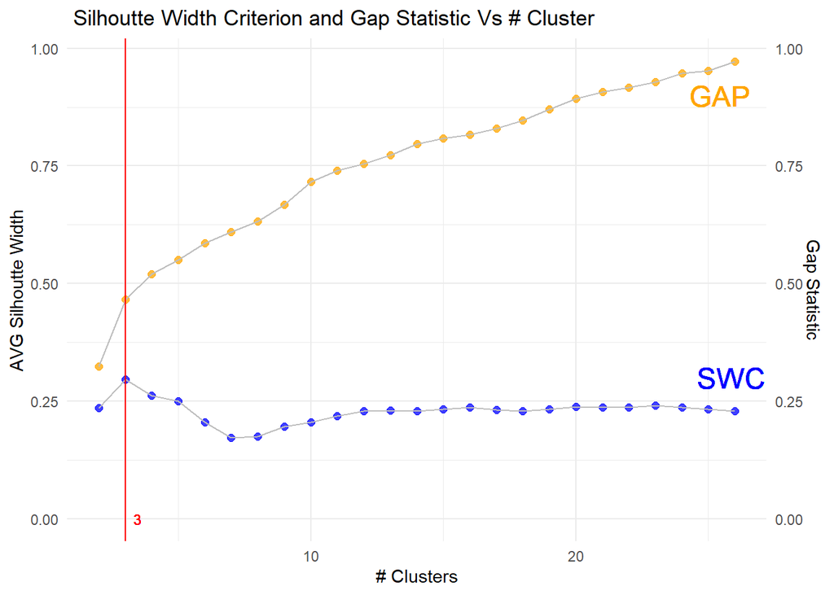

It can be seen that the model is very accurate in predicting the classes with an overall accuracy of 97% and only 2 missclassified observations. Now that the accuracy of the model has been confirmed we can use it to further explore the data. As well as visualizing the model to help interpret it and its data we will explore if the current classifications are statistically the “best”. Interestingly 2 clusters is not the mathematically best fitting classification, with 3 clusters showing closer clusters. While there are many criteria for selecting the optimal Gap statistic, it is interesting to note the change in slope of the gap statistic at the same number of clusters. To further explor the clustering results we will plot the heirarchy as a dendogram.

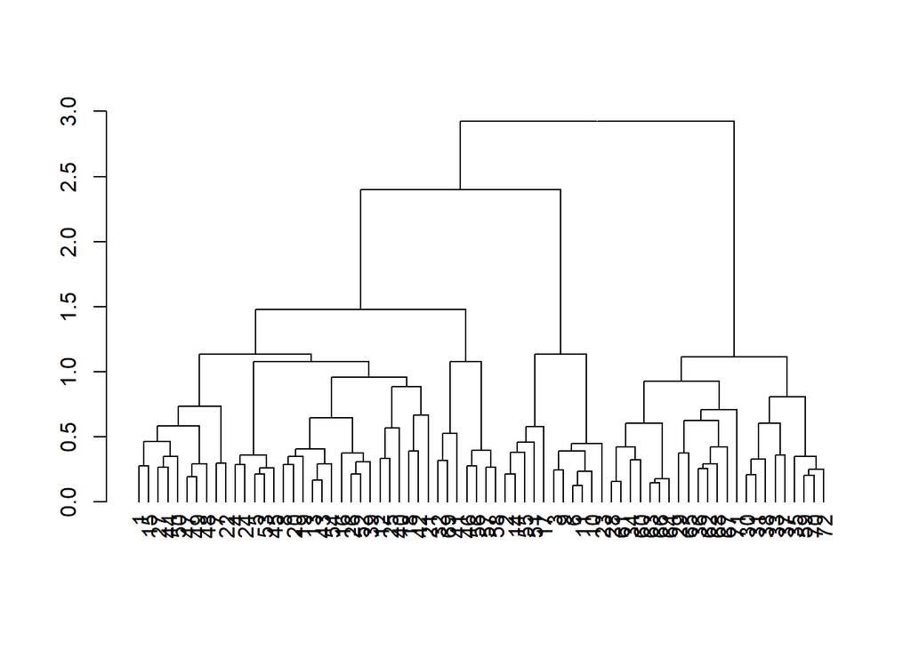

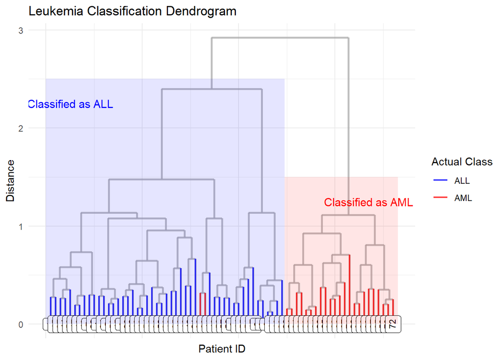

## Appendix 2

[output not shown]